# practical_exercise_8 , Methods 3, 2021, autumn semester

Sille Hasselbalch Markussen

01.12.21

# Exercises and objectives

1. Load the magnetoencephalographic recordings and do some initial plots to understand the data
2. Do logistic regression to classify pairs of PAS-ratings
3. Do a Support Vector Machine Classification on all four PAS-ratings

REMEMBER: In your report, make sure to include code that can reproduce the answers requested in the exercises below (**MAKE A KNITTED VERSION**)  
REMEMBER: This is Assignment 3 and will be part of your final portfolio

```r
library('reticulate')
```

# EXERCISE 1 - Load the magnetoencephalographic recordings and do some initial plots to understand the data

The files `megmag_data.npy` and `pas_vector.npy` can be downloaded here (http://laumollerandersen.org/data_methods_3/megmag_data.npy) and here (http://laumollerandersen.org/data_methods_3/pas_vector.npy)

1. Load `megmag_data.npy` and call it `data` using `np.load`. You can use `join`, which can be imported from `os.path`, to create paths from different string segments

```python
import numpy as np
import matplotlib.pyplot as plt

data = np.load('/Users/Sillemarkussen/Desktop/Methods_3/megmag_data.npy')
```

[output not shown]

```python
data.shape
```

```
## (682, 102, 251)
```

The first dimension consists of 682 repetitions of visual stimulus, the second consists of 102 sensors and the third of 251 time samples.

```
ii. The time range is from (and including) -200 ms to (and including) 800 ms with a sample recorded every 4 ms. At time 0, the visual stimulus was briefly presented. Create a 1-dimensional array called `times` that represents this.
```

```python
times = np.arange(-200, 804, 4) #804 for it to include 800 :)
```

[output not shown]

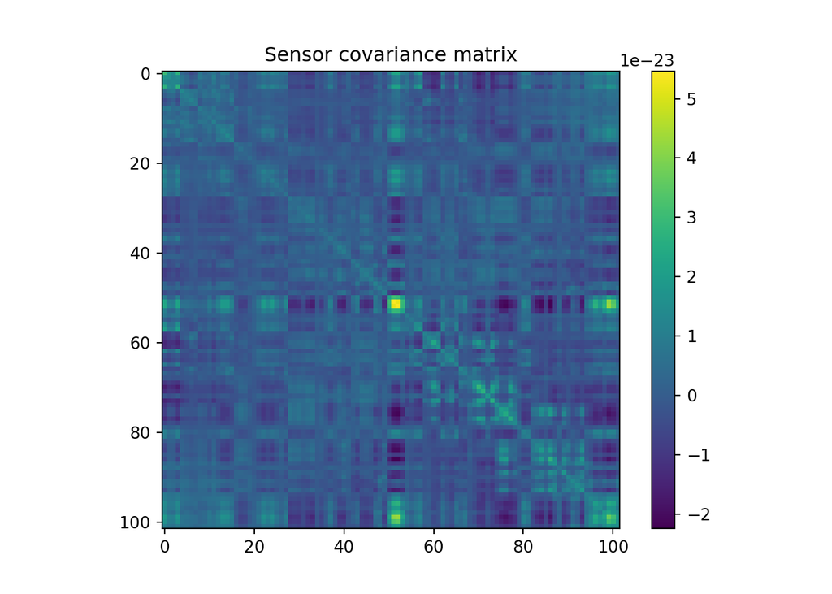

```python
# Creating an empty matrix which has the size as an sxs matrix
cov_init = np.zeros(shape = (102,102))

# Starting to create the covariance matrix by looping over each of the repetitions
for i in range(682):
  X = data[i]
  cov_init += X@(np.transpose(X))

# Multiplying the current covariance matrix with 1 over the number of repetitions to complete the formula
cov_var = 1/682*cov_init

# Plotting
plt.figure()
plt.imshow(cov_var)
plt.colorbar()
plt.title("Sensor covariance matrix")
plt.show()
```

From the covariance plot it is visible that the shared variance between the sensors is rarely exactly zero. Therefore, it does not seem to be the case that the sensors pick up independent signals.  
iv. Make an average over the repetition dimension using `np.mean` - use the `axis` argument. (The resulting array should have two dimensions with time as the first and magnetic field as the second)

```python
# Array containing the average over axis 0 (repetitions)
average_rep = np.mean(data, axis = 0)
```

```
v. Plot the magnetic field (based on the average) as it evolves over time for each of the sensors (a line for each) (time on the x-axis and magnetic field on the y-axis). Add a horizontal line at $y = 0$ and a vertical line at $x = 0$ using `plt.axvline` and `plt.axhline`
```

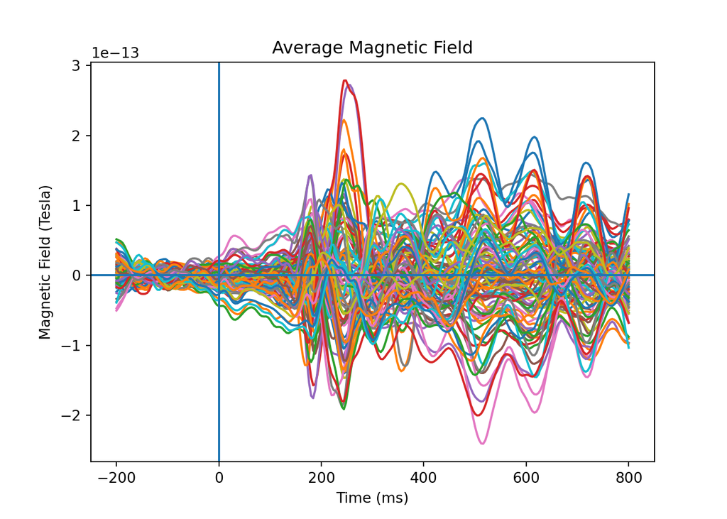

```python
plt.figure()
plt.plot(times, average_rep.T) #T tranposes so that the dimensions match
plt.axvline()
plt.axhline()
plt.title("Average Magnetic Field")
plt.xlabel("Time (ms)")
plt.ylabel("Magnetic Field (Tesla)")
plt.show()
```

vi. Find the maximal magnetic field in the average. Then use `np.argmax` and `np.unravel_index` to find the sensor that has the maximal magnetic field.

```python
# Maximal magnetic field in tesla
average_rep.max()

# The sensor that has the maximal magnetic field
# Finding the sensor that has the maximal magnetic field. np.argmax returns a single number from a flat array with all the sensor numbers stacked stacked on top of each other.
```

```
## 2.7886216843591933e-13
```

```python
ind = np.argmax(average_rep)

# Unraveling the flattened index to find the coordinates for the maximal magnetic field
np.unravel_index(ind, (102,251))
```

```
## (73, 112)
```

The maximal magnetic field is $2.79e^{-13}$ and it is the $73^{th}$ sensor that has the maximal magnetic field.  
vii. Plot the magnetic field for each of the repetitions (a line for each) for the sensor that has the maximal magnetic field. Highlight the time point with the maximal magnetic field in the average (as found in 1.1.v) using `plt.axvline`

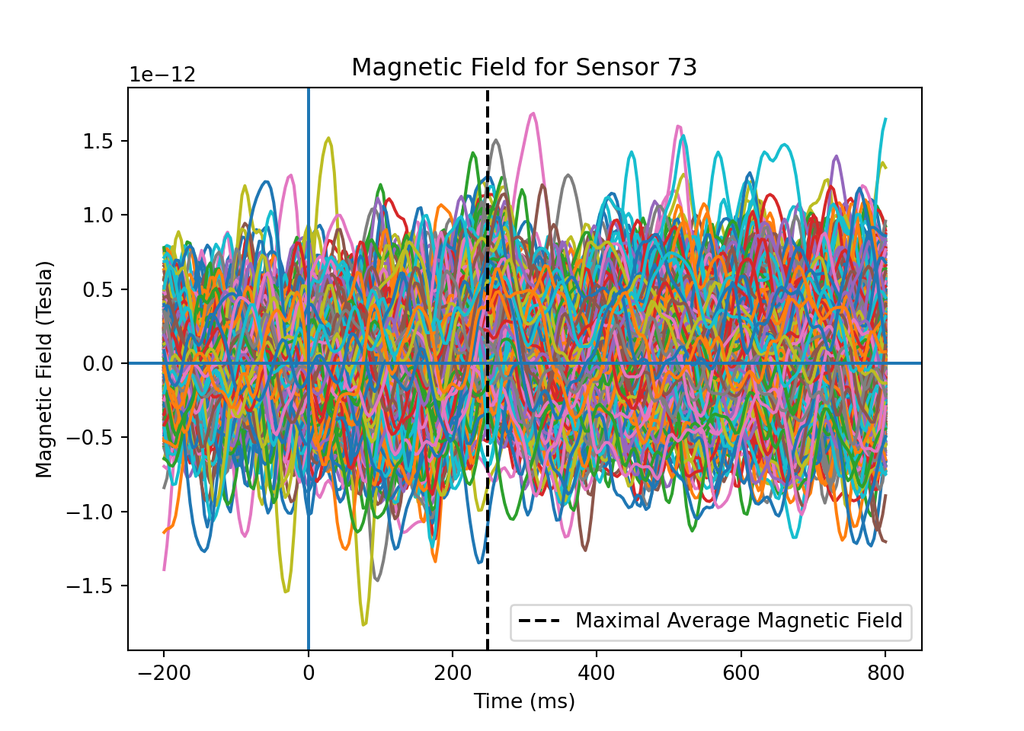

```
viii. Describe in your own words how the response found in the average is represented in the single repetitions. But do make sure to use the concepts _signal_ and _noise_ and comment on any differences on the range of values on the y-axis
```

```python
# Creating an array with each repetition at each time point for sensor number 73
sensor_73 = data[:,73,:]


plt.figure()
plt.plot(times, sensor_73.T) #T transposes so that the dimensions match
plt.axvline(248, color='k', linestyle="--", label ='Maximal Average Magnetic Field')
plt.axvline()
plt.axhline()
plt.title("Magnetic Field for Sensor 73")
plt.xlabel("Time (ms)")
plt.ylabel("Magnetic Field (Tesla)")
plt.legend()
plt.show()
```

The plot depicts the 682 repetitions for sensor 73. The average of all of these repetitions was illustrated by the red line, sensor 73 with the highest peak in the plot in exercise 1.1.v. Since there is a lot of noise in the measurements in each repetition it is difficult to notice the time point for maximal magnetic field for the average. However, knowing the maximal average magnetic field, there does seem to be less negative fluctuations and slightly more positive. For a stronger signal, the previous plot showing the average is preferable since we average out some noise.

2. Now load `pas_vector.npy` (call it `y`). PAS is the same as in Assignment 2, describing the clarity of the subjective experience the subject reported after seeing the briefly presented stimulus

```python
y = np.load("pas_vector.npy")
```

```
i. Which dimension in the `data` array does it have the same length as?
```

```python
y.shape
```

```
## (682,)
```

The same as the number of repetitions of visual stimulus which is the first dimension of the three dimensional array.

ii. Now make four averages (As in Exercise 1.1.iii), one for each PAS rating, and plot the four time courses (one for each PAS rating) for the sensor found in Exercise 1.1.v

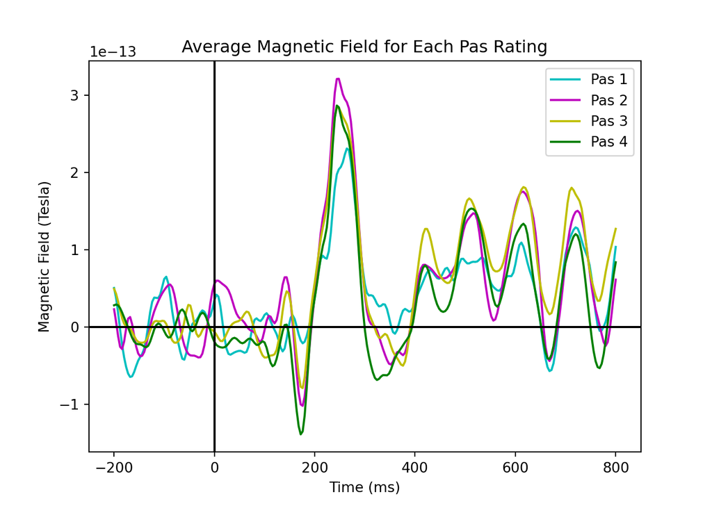

```
iii. Notice that there are two early peaks (measuring visual activity from the brain), one before 200 ms and one around 250 ms. Describe how the amplitudes of responses are related to the four PAS-scores. Does PAS 2 behave differently than expected?
```

```python
# Finding the indices belonging to each pas
pas_1 = np.where(y == 1)
pas_2 = np.where(y == 2)
pas_3 = np.where(y == 3)
pas_4 = np.where(y == 4)

# Finding averages for each pas
average_pas_1 = np.mean(sensor_73[pas_1], axis = 0)
average_pas_2 = np.mean(sensor_73[pas_2], axis = 0)
average_pas_3 = np.mean(sensor_73[pas_3], axis = 0)
average_pas_4 = np.mean(sensor_73[pas_4], axis = 0)

# Plotting
plt.figure()
plt.plot(times, average_pas_1, color = 'c', label = 'Pas 1')
plt.plot(times, average_pas_2, color = 'm', label = 'Pas 2')
plt.plot(times, average_pas_3, color = 'y', label = 'Pas 3')
plt.plot(times, average_pas_4, color = 'g', label = 'Pas 4')
plt.legend()
plt.axvline(color = 'k')
plt.axhline(color = 'k')
plt.title("Average Magnetic Field for Each Pas Rating")
plt.xlabel("Time (ms)")
plt.ylabel("Magnetic Field (Tesla)")
plt.show()
```

The amplitudes of the peaks is tightly related to the four pas-ratings. Pas 1 has the lowest amplitude, which fits the assumption that less activity is measured when the participant rated no perceptual awareness. Contrary, higher amplitudes are visible for pass 3 and 4 also fitting the assumption of more activity related to greater perceptual awareness. The amplitude for pas 2 is surprising. It would be expected of pas 2 to have a lower peak compared to pas 3 and 4 since it indicates lower rated perceptual awareness.

# EXERCISE 2 - Do logistic regression to classify pairs of PAS-ratings

1. Now, we are going to do Logistic Regression with the aim of classifying the PAS-rating given by the subject
   1. We’ll start with a binary problem - create a new array called `data_1_2` that only contains PAS responses 1 and 2. Similarly, create a `y_1_2` for the target vector

```python
from array import *

# List of indices from pas 1 and 2
pas_1_2 = pas_1[0].tolist() + pas_2[0].tolist()

# Sorting to get the right order
pas_1_2.sort()

# Creating the data array by extracting the indices from data that was rated pas 1 or 2
data_1_2 = data[pas_1_2]

# Creating the target vector
y_1_2 = y[pas_1_2]
```

[output not shown]

```python
#
X_1_2 = data_1_2.copy()
X_1_2.shape = X_1_2.shape[0],-1

# Checking the shape
X_1_2.shape
```

```
## (214, 25602)
```

```
iii. Import the `StandardScaler` and scale `X_1_2`
```

```python
from sklearn.preprocessing import  StandardScaler
```

```
iv. Do a standard `LogisticRegression` - can be imported from `sklearn.linear_model` - make sure there is no `penalty` applied
```

```python
# Standardizing
sc = StandardScaler()
sc.fit(X_1_2)
```

```
## StandardScaler()
```

```python
X_1_2_std = sc.transform(X_1_2)

# Importing LogisticRegression
from sklearn.linear_model import LogisticRegression

# Doing a standard linear regression
logR = LogisticRegression(penalty='none')
logR.fit(X_1_2_std, y_1_2)
```

```
## LogisticRegression(penalty='none')
```

```
v. Use the `score` method of `LogisticRegression` to find out how many labels were classified correctly. Are we overfitting? Besides the score, what would make you suspect that we are overfitting?
```

```python
print(logR.score(X_1_2_std, y_1_2))
```

```
## 1.0
```

The classification score of 1 indicates that all predictions are correct. Given that the model is tested on the data used to fit the model it is not a surprising score. Another indication of overfitting is the 25k features for ~200 rows.

```
vi. Now apply the _L1_ penalty instead - how many of the coefficients (`.coef_`) are non-zero after this?
```

```python
np.random.seed(7)

logR_L1 = LogisticRegression(penalty='l1', solver='liblinear')
logR_L1.fit(X_1_2_std, y_1_2)
```

```
## LogisticRegression(penalty='l1', solver='liblinear')
```

```python
coef = logR_L1.coef_

coef_non_zero = np.count_nonzero(coef)

print(coef_non_zero)
```

```
## 271
```

There are 271 non-zero coefficients.

```
vii. Create a new reduced $X$ that only includes the non-zero coefficients - show the covariance of the non-zero features (two covariance matrices can be made; $X_{reduced}X_{reduced}^T$ or $X_{reduced}^TX_{reduced}$ (you choose the right one)) . Plot the covariance of the features using `plt.imshow`. Compared to the plot from 1.1.iii, do we see less covariance?
```

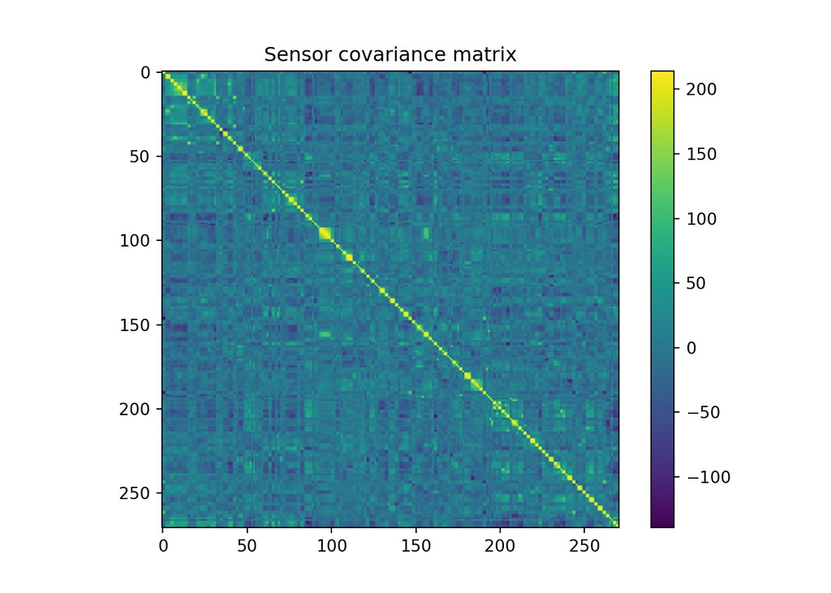

```python
# Creating the reduced X

# Finding the indices for the non-zero coefficients
index_non_zero = np.where(coef != 0)[1]

# Using the indices to find the supset the values from
X_1_2_nz = X_1_2_std[:,index_non_zero]


# Plotting covariance matrix
covar = (np.transpose(X_1_2_nz))@X_1_2_nz

plt.figure()
plt.imshow(covar)
plt.colorbar()
plt.title("Sensor covariance matrix")
plt.show()
```

The covariance of the non-zero features was calculated by $X_{reduced}^TX_{reduced}$ since there are 271 features. It is difficult to compare the two matrices since the variables are on different scales. However, it seems that more shared variance is found between the features than the between the sensors. Thus, there is not seen less covariance compared to the plot from 1.1.iii.

2. Now, we are going to build better (more predictive) models by using cross-validation as an outcome measure
   1. Import `cross_val_score` and `StratifiedKFold` from `sklearn.model_selection`

```python
from sklearn.model_selection import cross_val_score, StratifiedKFold
```

[output not shown]

```python
# Exercise 2.2.ii
def equalize_targets_binary(data, y):
    np.random.seed(7)
    targets = np.unique(y) ## find the number of targets
    if len(targets) > 2:
        raise NameError("can't have more than two targets")
    counts = list()
    indices = list()
    for target in targets:
        counts.append(np.sum(y == target)) ## find the number of each target
        indices.append(np.where(y == target)[0]) ## find their indices
    min_count = np.min(counts)
    # randomly choose trials
    first_choice = np.random.choice(indices[0], size=min_count, replace=False)
    second_choice = np.random.choice(indices[1], size=min_count,replace=False)

    # create the new data sets
    new_indices = np.concatenate((first_choice, second_choice))
    new_y = y[new_indices]
    new_data = data[new_indices, :, :]

    return new_data, new_y
```

```python
np.random.seed(3)
X_1_2_equal, y_1_2_equal = equalize_targets_binary(data_1_2, y_1_2)

# Copying the three dimensional X_1_2_equal
X_1_2_equal_3d = X_1_2_equal.copy()

# Collapsing the sensor and the time dimensions to be able to scale
X_1_2_equal_3d.shape = X_1_2_equal_3d.shape[0],-1

# Scaling X_1_2_equal
sc = StandardScaler()
sc.fit(X_1_2_equal_3d)
```

```
## StandardScaler()
```

```python
X_1_2_equal_std = sc.transform(X_1_2_equal_3d)
```

```
iii. Do cross-validation with 5 stratified folds doing standard `LogisticRegression` (See Exercise 2.1.iv)
```

```python
cv = StratifiedKFold()

logR_5 = LogisticRegression()
scores_5 = cross_val_score(logR_5, X_1_2_equal_std, y_1_2_equal, cv=cv)
print(np.mean(scores_5))
```

```
## 0.5402564102564102
```

```python
print(scores_5)
```

```
## [0.625      0.55       0.475      0.58974359 0.46153846]
```

```
iv. Do L2-regularisation with the following `Cs=  [1e5, 1e1, 1e-5]`. Use the same kind of cross-validation as in Exercise 2.2.iii. In the best-scoring of these models, how many more/fewer predictions are correct (on average)?
```

```python
Cs = [1e5, 1e1, 1e-5]

logR_l2_1e5 = LogisticRegression(C=Cs[0])
scores_l2_1e5 = cross_val_score(logR_l2_1e5, X_1_2_equal_std, y_1_2_equal, cv=cv)
print(np.mean(scores_l2_1e5))
```

```
## 0.5353846153846155
```

```python
logR_l2_1e1 = LogisticRegression(C=Cs[1])
scores_l2_1e1 = cross_val_score(logR_l2_1e1, X_1_2_equal_std, y_1_2_equal, cv=cv)
print(np.mean(scores_l2_1e1))
```

```
## 0.5252564102564102
```

```python
logR_l2_1e_5 = LogisticRegression(C=Cs[2])
scores_l2_1e_5 = cross_val_score(logR_l2_1e_5, X_1_2_equal_std, y_1_2_equal, cv=cv)
print(np.mean(scores_l2_1e_5))
```

```
## 0.5956410256410256
```

```python
# Finding the number of correctly predicted instances
(np.mean(scores_l2_1e5))*(len(y_1_2_equal))
```

```
## 106.00615384615386
```

```python
(np.mean(scores_l2_1e1))*(len(y_1_2_equal))
```

```
## 104.00076923076922
```

```python
(np.mean(scores_l2_1e_5))*(len(y_1_2_equal))
```

```
## 117.93692307692307
```

The best scoring model is correctly predicting accordingly approximately 12 and 14 instances.

```
v. Instead of fitting a model on all `n_sensors * n_samples` features, fit  a logistic regression (same kind as in Exercise 2.2.iv (use the `C` that resulted in the best prediction)) for __each__ time sample and use the same cross-validation as in Exercise 2.2.iii.
What are the time points where classification is best? Make a plot with time on the x-axis and classification score on the y-axis with a horizontal line at the chance level (what is the chance level for this analysis?)
```

```python
# fitting a logistic regression for each time sample
class_scores = []

for i in range(251):
  # scaling data for regression
  dat_l2 = X_1_2_equal[:,:,i]
  dat_l2 = sc.fit_transform(dat_l2)

  # regression
  logR_l2 = LogisticRegression(C=1e-5)
  scores = cross_val_score(logR_l2, dat_l2, y_1_2_equal, cv=cv)
  mean = np.mean(scores)
  class_scores.append(mean)
```

```python
# Finding the time points where classification is best
times[class_scores.index(max(class_scores))]
```

```
## 232
```

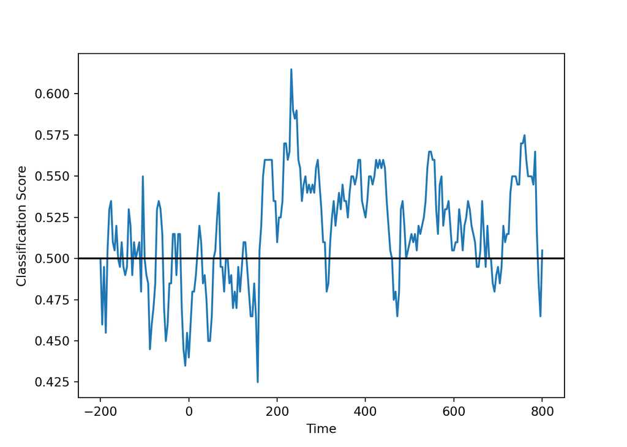

```python
plt.figure()
plt.plot(times, class_scores)
plt.axhline(0.5, color = 'k')
plt.xlabel("Time")
plt.ylabel("Classification Score")
plt.show()
```

The time point for best classification is recorded 232 ms after the onset of the stimuli. Given the that the classification predictions are binary and equalized amount chance level accuracy is 50%.

```
vi. Now do the same, but with L1 regression - set `C=1e-1` - what are the time points when classification is best? (make a plot)?
```

```python
# fitting a logistic regression for each time sample
class_scores_l1 = []

for i in range(251):
  # scaling data for regression
  dat_l1 = X_1_2_equal[:,:,i]
  dat_l1 = sc.fit_transform(dat_l1)

  # regression
  logR_l1 = LogisticRegression(penalty='l1', C=1e-1, solver='liblinear')
  scores_l1 = cross_val_score(logR_l1, dat_l1, y_1_2_equal, cv=cv)
  mean_l1 = np.mean(scores_l1)
  class_scores_l1.append(mean_l1)
```

```python
# Finding the time points where classification is best
times[class_scores_l1.index(max(class_scores_l1))]
```

```
## 244
```

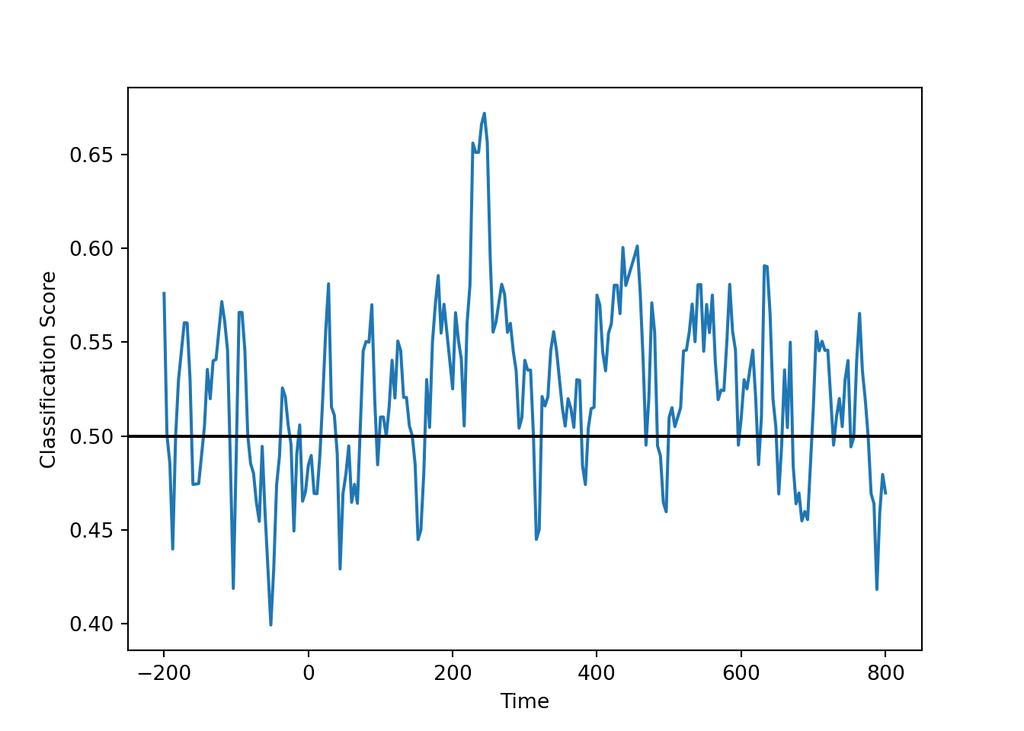

```python
# Plotting
plt.figure()
plt.plot(times, class_scores_l1)
plt.axhline(0.5, color = 'k')
plt.xlabel("Time")
plt.ylabel("Classification Score")
plt.show()
```

The time point for best classification is recorded 244 ms after the onset of the stimuli.  
vii. Finally, fit the same models as in Exercise 2.2.vi but now for `data_1_4` and `y_1_4` (create a data set and a target vector that only contains PAS responses 1 and 4). What are the time points when classification is best? Make a plot with time on the x-axis and classification score on the y-axis with a horizontal line at the chance level (what is the chance level for this analysis?)

```python
# List of indices from pas 1 and 4
pas_1_4 = pas_1[0].tolist() + pas_4[0].tolist()

# Sorting to get the right order
pas_1_4.sort()

# Creating the data array by extracting the indices from data that was rated pas 1 or 4
data_1_4 = data[pas_1_4]

# Creating the target vector
y_1_4 = y[pas_1_4]

# Equalizing
X_1_4_equal, y_1_4_equal = equalize_targets_binary(data_1_4, y_1_4)
```

```python
# fitting a logistic regression for each time sample
class_scores_1_4 = []

for i in range(251):
  # scaling data for regression
  dat_1_4 = X_1_4_equal[:,:,i]
  dat_1_4 = sc.fit_transform(dat_1_4)

  # regression
  logR_1_4 = LogisticRegression(penalty='l1', C=1e-1, solver='liblinear')
  scores_1_4 = cross_val_score(logR_1_4, dat_1_4, y_1_4_equal, cv=cv)
  mean_1_4 = np.mean(scores_1_4)
  class_scores_1_4.append(mean_1_4)

# Finding the time points where classification is best
times[class_scores_1_4.index(max(class_scores_1_4))]
```

```
## 236
```

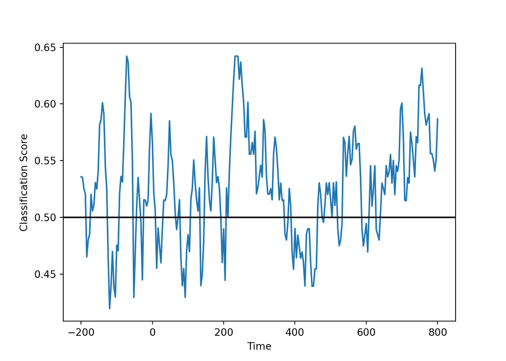

```python
# Plotting
plt.figure()
plt.plot(times, class_scores_1_4)
plt.axhline(0.5, color = 'k')
plt.xlabel("Time")
plt.ylabel("Classification Score")
plt.show()
```

The time point for best classification is recorded 236 ms after the onset of the stimuli.

3. Is pairwise classification of subjective experience possible? Any surprises in the classification accuracies, i.e. how does the classification score fore PAS 1 vs 4 compare to the classification score for PAS 1 vs 2?

```python
np.mean(class_scores_1_4)
```

```
## 0.5269077536009807
```

```python
np.mean(class_scores_l1)
```

```
## 0.5234921851057309
```

```python
np.max(class_scores_1_4)
```

```
## 0.6423076923076924
```

```python
np.max(class_scores_l1)
```

```
## 0.6720512820512822
```

# EXERCISE 3 - Do a Support Vector Machine Classification on all four PAS-ratings

1. Do a Support Vector Machine Classification
   1. First equalize the number of targets using the function associated with each PAS-rating using the function associated with Exercise 3.1.i

```python
def equalize_targets(data, y):
    np.random.seed(7)
    targets = np.unique(y)
    counts = list()
    indices = list()
    for target in targets:
        counts.append(np.sum(y == target))
        indices.append(np.where(y == target)[0])
    min_count = np.min(counts)
    first_choice = np.random.choice(indices[0], size=min_count, replace=False)
    second_choice = np.random.choice(indices[1], size=min_count, replace=False)
    third_choice = np.random.choice(indices[2], size=min_count, replace=False)
    fourth_choice = np.random.choice(indices[3], size=min_count, replace=False)

    new_indices = np.concatenate((first_choice, second_choice,
                                 third_choice, fourth_choice))
    new_y = y[new_indices]
    new_data = data[new_indices, :, :]

    return new_data, new_y
```

```python
# Equalizing data
X_all_pas_equal, y_all_pas_equal = equalize_targets(data, y)
```

```
ii. Run two classifiers, one with a linear kernel and one with a radial basis (other options should be left at their defaults) - the number of features is the number of sensors multiplied the number of samples. Which one is better predicting the category?
```

```python
# Collapsing the sensor and the time dimensions to be able to scale
X_all_pas_equal_3d = X_all_pas_equal.copy()
X_all_pas_equal_3d.shape = X_all_pas_equal_3d.shape[0],-1

# Scaling equalized data
sc = StandardScaler()
X_all_pas_std = sc.fit_transform(X_all_pas_equal_3d)
```

```python
from sklearn.svm import SVC

# Linear kernel
svm = SVC(kernel='linear')
scores_svm = cross_val_score(svm, X_all_pas_std, y_all_pas_equal, cv=cv)
print(np.mean(scores_svm))

# Radial basis
```

```
## 0.2928164556962025
```

```python
svm = SVC(kernel='rbf')
scores_svm = cross_val_score(svm, X_all_pas_std, y_all_pas_equal, cv=cv)
print(np.mean(scores_svm))
```

```
## 0.3333544303797468
```

The classifier with the radial basis is better at predicting the category with an accuracy of 33.33%

```
iii. Run the sample-by-sample analysis (similar to Exercise 2.2.v) with the best kernel (from Exercise 3.1.ii). Make a plot with time on the x-axis and classification score on the y-axis with a horizontal line at the chance level (what is the chance level for this analysis?)
```

```python
# fitting a logistic regression for each time sample
class_scores_3_iii = []

for i in range(251):
  # scaling data for regression
  dat_3_iii = X_all_pas_equal[:,:,i]
  dat_3_iii = sc.fit_transform(dat_3_iii)

  # regression
  svm = SVC(kernel='rbf')
  scores_svm = cross_val_score(svm, dat_3_iii, y_all_pas_equal, cv=cv)
  mean = np.mean(scores_svm)
  class_scores_3_iii.append(mean)
```

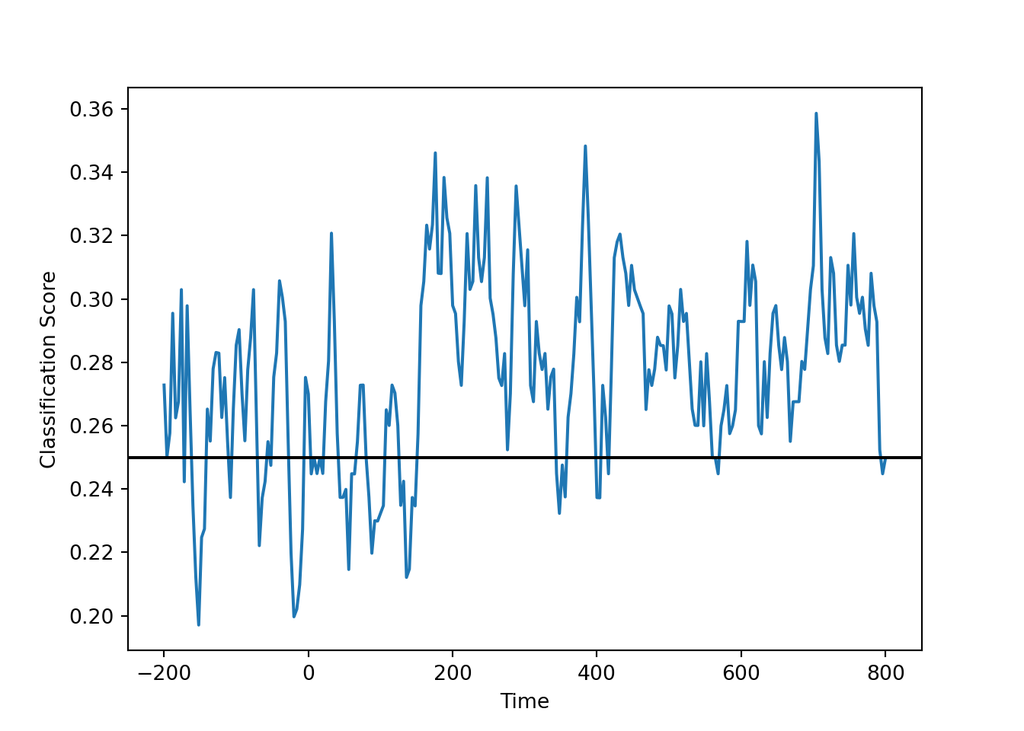

```python
# Plotting
plt.figure()
plt.plot(times, class_scores_3_iii)
plt.axhline(0.25, color = 'k')
plt.xlabel("Time")
plt.ylabel("Classification Score")
plt.show()
```

Classifying the four pas ratings must have a chance level at $100/4=25$%

```
iv. Is classification of subjective experience possible at around 200-250 ms?
```

Looking at the plot it is visible that classification scores are above chance level around 200-250 ms.

```python
lower = np.where(times == 200)[0][0]
upper = np.where(times == 248)[0][0]

np.mean(class_scores_3_iii[lower:upper])
```

```
## 0.30297468354430374
```

The average classification score in the interval is 30%. This is above chance level so classification of subjective experience is arguably possible at around 200-250 ms.

2. Finally, split the equalized data set (with all four ratings) into a training part and test part, where the test part if 30 % of the trials. Use `train_test_split` from `sklearn.model_selection`

```python
from sklearn.model_selection import train_test_split

X_train, X_test, y_train, y_test = train_test_split(X_all_pas_std, y_all_pas_equal, test_size=0.3, random_state=42, stratify =y_all_pas_equal)
```

```
i. Use the kernel that resulted in the best classification in Exercise 3.1.ii and `fit`the training set and `predict` on the test set. This time your features are the number of sensors multiplied by the number of samples.
```

```python
svm = SVC(kernel='rbf')
svm.fit(X_train, y_train)
```

```
## SVC()
```

```python
predicted = svm.predict(X_test)
```

[output not shown]

```python
from sklearn.metrics import confusion_matrix, plot_confusion_matrix

plt.figure()
plot_confusion_matrix(svm, X_test, y_test)
```

```
## <sklearn.metrics._plot.confusion_matrix.ConfusionMatrixDisplay object at 0x13f4c9e80>
##
```

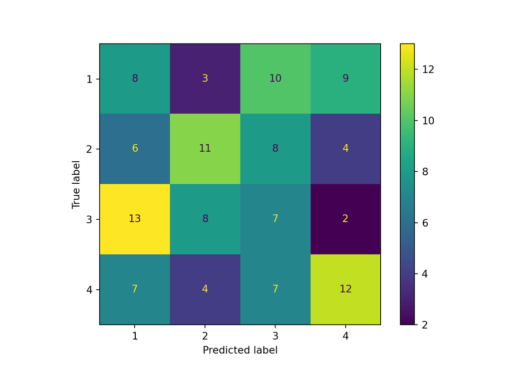

```
iii. Based on the confusion matrix, describe how ratings are misclassified and if that makes sense given that ratings should measure the strength/quality of the subjective experience. Is the classifier biased towards specific ratings?
```

```python
plt.show()
```